# Bolas_Lab_2

Ellie Bolas, GEO200CN, Spring 2017

```r
knitr::opts_chunk$set(echo = TRUE, warning = FALSE, eval = TRUE)
knitr::opts_knit$set(root.dir = normalizePath("../"))
#always looking from the perspective of where the rmd is, "../" says look outside of this folder
#~ is a shortcut for your home directory/root folder
library(readr)
library(dplyr)
```

# Pointers from Elise

```r
a<- 1:5
b<- 6:10
a*b #multiplies element-wise
```

```
## [1]  6 14 24 36 50
```

```r
c<- 1:10
a+c #"c" is larger, when it runs out of elements from "a," it starts back over at the beginning of "a"
```

```
##  [1]  2  4  6  8 10  7  9 11 13 15
```

_x_Carefully read chapter 7 to 14 in http://rspatial.org/intr/ __

# x__1) Functions+Apply__

1. Use the files from lab 1 to compute mean values for each variable using ‘apply’

```r
datapath <- "../GEO200CN/data"


lob1<- read.table(file.path(datapath, "loblolly.dat"), header = TRUE)

#file.path uses the complete path only to its folder


chick1<- read.csv(file.path(datapath, "ChickWeightSub.csv"))
```

```r
apply(lob1, 2, mean)
```

```
##   height      age     Seed
##  32.3644  13.0000 316.1429
```

```r
apply(chick1, 2, mean)
```

```
##     Weight     DayOld    ChickID     DietID
## 106.833333   9.000000  27.777778   2.333333
```

2. Write a function ‘f’ that behaves like this:

> f(‘Sarah’) [1] “hello Sarah, how are you”

```r
f<-function(name) {
  x<- paste("hello ", name,", how are you", sep = "")
  return(x)
}

f("Sarah")
```

```
## [1] "hello Sarah, how are you"
```

```r
#paste0() seperator is set to be nothing

d<-function(name) {
   x<- paste0("hello ", name, ",", " how are you")
   return(x)
}

d("Ellie")
```

```
## [1] "hello Ellie, how are you"
```

3. Write a function ‘sumOfSquares’ that behaves like this:

> d <- c(1,5,2,4,6,2,4,5) sumOfSquares(d) [1] 21.875

To compute the “sum of squares”, subtract the mean value of all numbers from each number. Square these numbers and sum them

```r
d <- c(1,5,2,4,6,2,4,5)
d
```

```
## [1] 1 5 2 4 6 2 4 5
```

```r
sumofSquares <- function(d) {
  meand <- mean(d)
  submean <- d-meand
  sqsum <- sum(submean*submean)
  return(sqsum)
}

sumofSquares(d)
```

```
## [1] 21.875
```

**2) Data preparation+exploration**. Use the data in “students.csv” and “scores.dat” to assess if there is a relation between the “group” or “age” of a student and their average score and for the three subjects (math, english, geography)

-just correlate between average and group and average and age

```r
scores <- read.table(file.path(datapath, "scores.dat"), header = TRUE, na.strings = c("", " ", "-999"))
#added na.strings later to turn -999 into an na so i could remove it

students1 <- read.csv(file.path(datapath, "students.csv"))

library(dplyr)
library(plyr)
```

1. use reshape and merge to combine the two data sets

```r
scores1 <- rename(scores, c("student" = "students"))

#students_joined <-full_join(students1, scores1, by = NULL) not useful right now

#need to turn scores1 from long > wide format
scores2 <- reshape(scores1, idvar = c("students"), timevar = "subject", direction = "wide")


#average <- scores2 %>% filter (!is.na(score.math)) %>% mutate(average = mean(c(score.math, score.english, score.geography))) this didn't work


#average_score <- scores2 %>% mutate(mean = rowMeans(scores2, na.rm = TRUE, dims =1)) doesn't work b/c scores2 is not numeric

scores2$mean <- rowMeans(scores2[,2:4], na.rm = TRUE) #yay

studentscores <- merge(scores2, students1, by = "students")

head(studentscores)
```

```
##   students score.math score.english score.geography     mean group age
## 1        A       10.0          10.0             5.2 8.400000     1  25
## 2        B        6.6           5.8             4.1 5.500000     1  20
## 3        C        5.4           7.2             5.4 6.000000     1  20
## 4        D        8.1           8.5            10.5 9.033333     2  22
## 5        E        7.5          10.0             8.5 8.666667     1  25
## 6        F         NA           6.6             6.6 6.600000     1  19
```

2. compute correlation coefficients
3. produce a relevant plot assess if there is a relation between the “group” or “age” of a student and their average score

```r
d <- lm(group ~ mean, data = studentscores)
d
```

```
##
## Call:
## lm(formula = group ~ mean, data = studentscores)
##
## Coefficients:
## (Intercept)         mean
##     1.17344      0.04718
```

```r
cor(studentscores$group, studentscores$mean) #this returns a different number...
```

```
## [1] 0.09538632
```

```r
m <- lm(age ~ mean, data = studentscores)
m
```

```
##
## Call:
## lm(formula = age ~ mean, data = studentscores)
##
## Coefficients:
## (Intercept)         mean
##     20.2908       0.2159
```

```r
cor(studentscores$age, studentscores$mean)#see above
```

```
## [1] 0.0928198
```

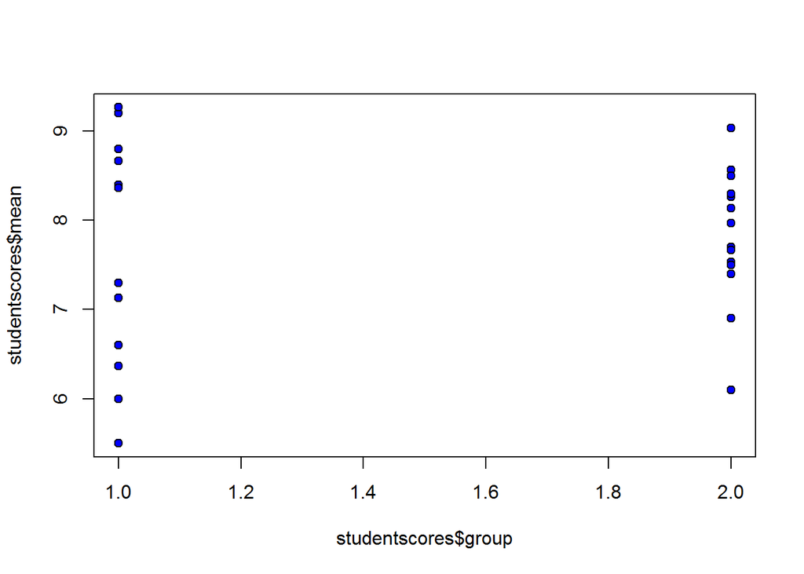

```r
plot(x = studentscores$group, y = studentscores$mean, pch = 21, bg="blue")
```

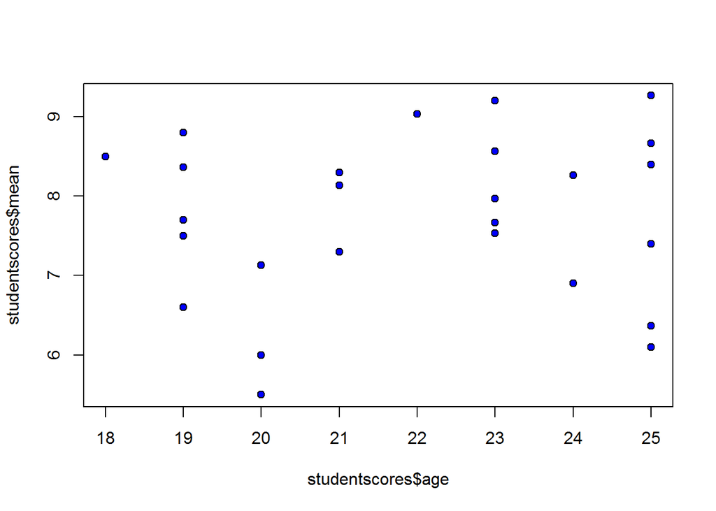

```r
#abline(d, col = "red", lwd = 2) doesn't work

plot(x = studentscores$age, y = studentscores$mean, pch = 21, bg="blue")
#abline(m, col= "red", lwd = 2) this doesn't seem to work
abline(a= 20.2908, b=0.2159) #not sure about how to add in this line
abline(lm(age ~ mean, data = studentscores), bg = "red")
```

_x_Hand in the results for #1 and #2 as a R Markdown file.__ Both the source file and an HTML file. You can complete the .Rmd file available on smartsite.